# 4th Floor Fantasy Draft 2026

Evan Oman

September 6, 2026

## Introduction

This document looks at how our league handled the 2026 Fantasy Football Draft. We have drafted without cheatsheets since 2016, so every manager has to arrive with their own plan. That setup leads to big swings in pick quality, which makes the draft a fun case study each year.

Throughout the analysis I use the ESPN Superflex PPR rankings as a proxy for player value. The list is far from perfect, but it serves as a consistent yardstick for comparing draft decisions.

Source code and data live at https://github.com/EvanOman/FantasyFootball, and you can reach me via http://www.evanoman.com.

Let the fun begin!

## Data Preparation

The draft data uses the confirmed eight-team snake order and includes all 128 picks. Fauxgendaz’s round-11 Etienne entry is treated as Travis Etienne Jr. (ESPN rank 45), based on Evan’s recollection that the higher-ranked Etienne was drafted. The supplied table contains only one Etienne entry.

Load the data:

```r
draftData <- read.csv("./data/Draft2026.csv", stringsAsFactors = FALSE)

# Align column names with the rest of the workflow
names(draftData)[names(draftData) == "OverallPick"] <- "PickNumber"
names(draftData)[names(draftData) == "Position"] <- "Pos"
names(draftData)[names(draftData) == "FantasyTeam"] <- "Drafter"

print.data.frame(head(draftData), row.names = FALSE)
```

```
##  PickNumber Round PickInRound              Player NFLTeam Pos      Drafter
##           1     1           1        Jahmyr Gibbs     DET  RB       Flames
##           2     1           2      Bijan Robinson     ATL  RB Clint Bilton
##           3     1           3      Saquon Barkley     PHI  RB         NKFL
##           4     1           4          Puka Nacua     LAR  WR   Fauxgendaz
##           5     1           5          Josh Allen     BUF  QB  Purple Rain
##           6     1           6 Christian McCaffrey      SF  RB  Rome Reigns
```

The file is already in the tall format we need, so we can move straight to the rankings.

For 2026 we use the September 2 ESPN PPR Superflex Top 300 from [Board Calls](https://evanoman.com/board-calls/). ESPN’s sheet assumes 10 teams; our draft has eight. Rankings provide the same comparison as last year’s report.

```r
rankings <- read.csv("./data/espn_superflex_ppr_2026.csv", stringsAsFactors = FALSE)

# Keep positional labels from the rankings distinct from the draft data
names(rankings)[names(rankings) == "Pos"] <- "RankPos"

# Read player as string, not factor
rankings$Player <- as.character(rankings$Player)

print.data.frame(head(rankings, n=10), row.names=FALSE)
```

```
##  Rank              Player RankPos
##     1          Josh Allen      QB
##     2      Jayden Daniels      QB
##     3       Lamar Jackson      QB
##     4        Jahmyr Gibbs      RB
##     5      Bijan Robinson      RB
##     6       Ja'Marr Chase      WR
##     7          Puka Nacua      WR
##     8  Jaxon Smith-Njigba      WR
##     9 Christian McCaffrey      RB
##    10          Drake Maye      QB
```

This dataset is also tall, so no additional reshaping is necessary. With both tables ready we join `draftData` and `rankings` on `Player`. Because this is a left join, every draft pick is retained even if the player falls outside the top 300. Names and positions are checked before export. The four players or defenses absent from the Top 300 use `nrow(rankings) + 1` (301) as a comparison value, following the previous report; 301 is not an observed ESPN rank.

```r
library("dplyr")
library("DT")

# Join rankings data with draft data
joinedData <- left_join(draftData, rankings, by="Player")

# Some players will not have a  ranking, give these players a worst ranking + 1
joinedData$Rank[is.na(joinedData$Rank)] <- nrow(rankings) + 1

print.data.frame(head(joinedData, n=10), row.names=FALSE)
```

```
##  PickNumber Round PickInRound              Player NFLTeam Pos        Drafter Rank RankPos
##           1     1           1        Jahmyr Gibbs     DET  RB         Flames    4      RB
##           2     1           2      Bijan Robinson     ATL  RB   Clint Bilton    5      RB
##           3     1           3      Saquon Barkley     PHI  RB           NKFL   28      RB
##           4     1           4          Puka Nacua     LAR  WR     Fauxgendaz    7      WR
##           5     1           5          Josh Allen     BUF  QB    Purple Rain    1      QB
##           6     1           6 Christian McCaffrey      SF  RB    Rome Reigns    9      RB
##           7     1           7      Jayden Daniels     WAS  QB Magic Skol Bus    2      QB
##           8     1           8      James Cook III     BUF  RB     Think Tank   18      RB
##           9     2           1     Jonathan Taylor     IND  RB     Think Tank   12      RB
##          10     2           2       Lamar Jackson     BAL  QB Magic Skol Bus    3      QB
```

The result contains every pick, its pick number, and the ESPN ranking. From here we can measure pick quality using the difference between those two numbers.

```r
joinedData$RankDiff <- joinedData$Rank - joinedData$PickNumber

print.data.frame(head(joinedData, n=10), row.names=FALSE)
```

```
##  PickNumber Round PickInRound              Player NFLTeam Pos        Drafter Rank RankPos RankDiff
##           1     1           1        Jahmyr Gibbs     DET  RB         Flames    4      RB        3
##           2     1           2      Bijan Robinson     ATL  RB   Clint Bilton    5      RB        3
##           3     1           3      Saquon Barkley     PHI  RB           NKFL   28      RB       25
##           4     1           4          Puka Nacua     LAR  WR     Fauxgendaz    7      WR        3
##           5     1           5          Josh Allen     BUF  QB    Purple Rain    1      QB       -4
##           6     1           6 Christian McCaffrey      SF  RB    Rome Reigns    9      RB        3
##           7     1           7      Jayden Daniels     WAS  QB Magic Skol Bus    2      QB       -5
##           8     1           8      James Cook III     BUF  RB     Think Tank   18      RB       10
##           9     2           1     Jonathan Taylor     IND  RB     Think Tank   12      RB        3
##          10     2           2       Lamar Jackson     BAL  QB Magic Skol Bus    3      QB       -7
```

With the data prepped we can move on to summarizing the draft.

## Figures and Results

A natural starting point is the average difference between pick number and rank for each drafter. We calculate that with `aggregate`.

```r
avgDiffs <- aggregate(RankDiff ~ Drafter, joinedData, FUN=mean)

# Order factor by worst draft to best
avgDiffs <- within(avgDiffs, Drafter <- factor(Drafter, levels=avgDiffs[order(avgDiffs$RankDiff), "Drafter"]))

# Order dataframe by worst draft to best
avgDiffs <- avgDiffs[order(avgDiffs$RankDiff, decreasing = FALSE),]

print.data.frame(avgDiffs, row.names=FALSE)
```

```
##         Drafter RankDiff
##     Purple Rain   2.5000
##     Rome Reigns   4.6250
##      Think Tank   5.1250
##    Clint Bilton  17.8125
##  Magic Skol Bus  18.5000
##            NKFL  41.5625
##      Fauxgendaz  57.3125
##          Flames  58.9375
```

From this table we learn that Purple Rain had the lowest average rank difference (his average pick was 2.5 slots earlier than the ESPN rank) while Flames struggled the most (averaging 58.9375 spots earlier than the ESPN rank). The bar chart below gives the same view at a glance.

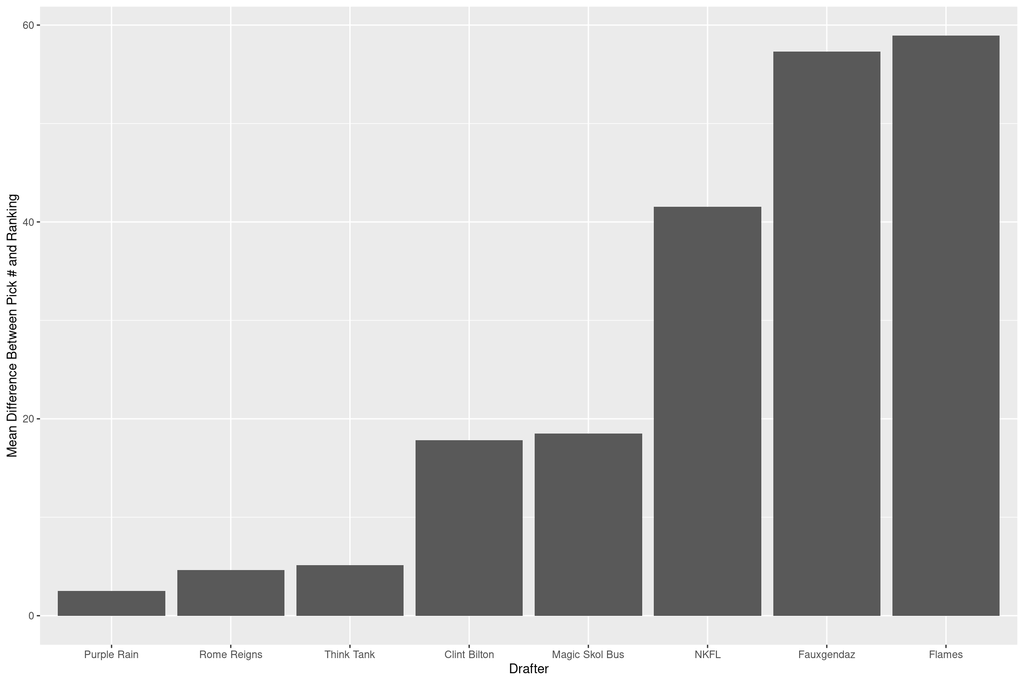

```r
library(ggplot2)
ggplot(avgDiffs, aes(x=Drafter, y=RankDiff)) + geom_bar(stat = "identity") + ylab("Mean Difference Between Pick # and Ranking")
```

Kickers and defenses affect the averages, so I also check the results after removing those positions:

```r
noKorDst <- joinedData[!(joinedData$Pos %in% c("DST", "K")), ]

avgDiffs2 <- aggregate(RankDiff ~ Drafter, noKorDst, FUN=mean)

# Order factor by worst draft to best
avgDiffs2 <- within(avgDiffs2, Drafter <- factor(Drafter, levels=avgDiffs[order(avgDiffs$RankDiff), "Drafter"]))

# Order dataframe by worst draft to best
avgDiffs2 <- avgDiffs2[order(avgDiffs2$RankDiff, decreasing = FALSE),]

print.data.frame(avgDiffs2, row.names=FALSE)
```

```
##         Drafter   RankDiff
##     Rome Reigns -11.928571
##     Purple Rain  -5.214286
##      Think Tank  -2.785714
##  Magic Skol Bus   6.928571
##    Clint Bilton  11.785714
##            NKFL  31.142857
##      Fauxgendaz  49.071429
##          Flames  49.714286
```

Next I look at positional trends to see which spots were over- or undervalued.

```r
posDiffs <- aggregate(RankDiff ~ Pos, joinedData, FUN=mean)

posDiffs <- within(posDiffs, Pos <- factor(Pos, levels=posDiffs[order(posDiffs$RankDiff), "Pos"]))

# Order dataframe by worst draft to best
posDiffs <- posDiffs[order(posDiffs$RankDiff, decreasing = FALSE),]

print.data.frame(posDiffs, row.names=FALSE)
```

```
##  Pos   RankDiff
##   QB  -7.285714
##   WR  17.380952
##   RB  21.138889
##   TE  35.692308
##  DST  85.625000
##    K 101.875000
```

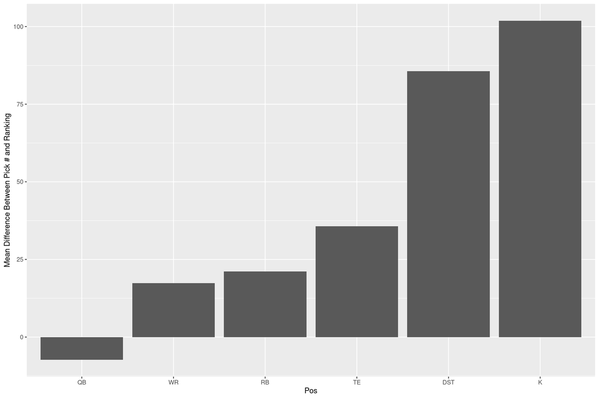

```r
ggplot(posDiffs, aes(x=Pos, y=RankDiff)) + geom_bar(stat = "identity") + ylab("Mean Difference Between Pick # and Ranking")
```

The chart shows that QB were under valued by 7.2857143 picks on average, while K were over valued by 101.875 picks.

The next two plots chart `Pick #` versus `Rank` with a diagonal “break-even” line. Points below the line were bargains; points above were reaches. The first plot highlights drafters and the second highlights positions.

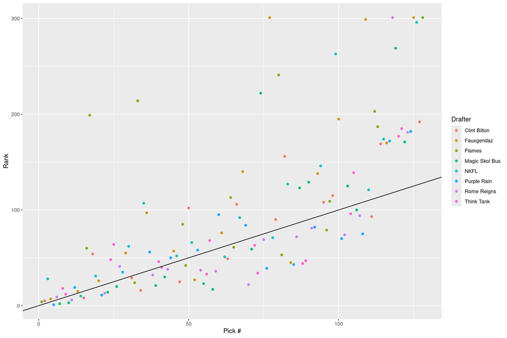

```r
# Scatter colored by drafter
ggplot(joinedData, aes(x=PickNumber,y=Rank)) + geom_point(aes(color=Drafter)) + geom_abline() + xlab("Pick #")
```

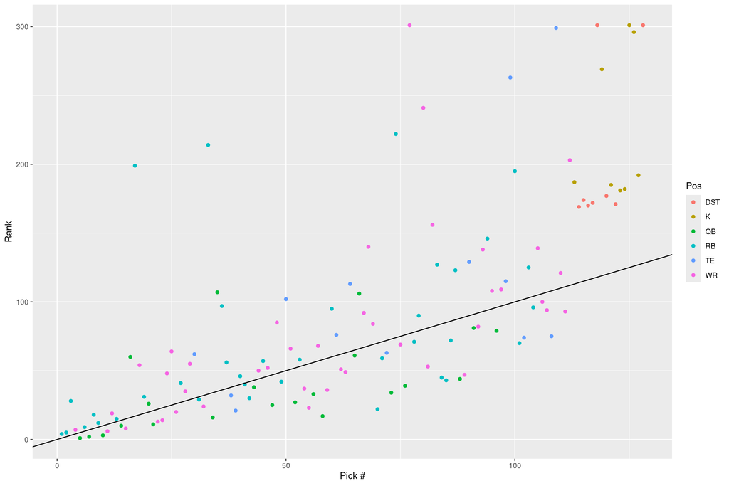

```r
# Scatter colored by position
ggplot(joinedData, aes(x=PickNumber,y=Rank)) + geom_point(aes(color=Pos)) + geom_abline() + xlab("Pick #")
```

The largest gaps show which picks differed most from ESPN’s rankings.

Finally, I look at the round-by-round swings for each drafter. In the figure below, anything below the dashed line is a win and anything above is a reach.

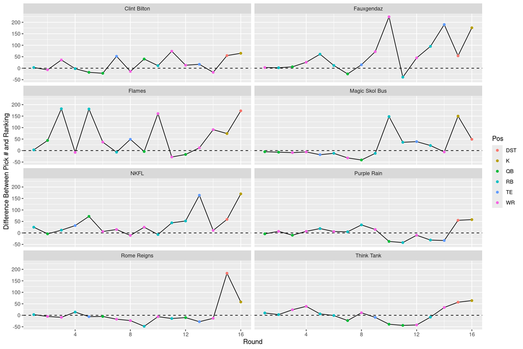

```r
# Scatter colored by position, faceted by drafter
ggplot(joinedData, aes(x=Round, y=RankDiff)) + geom_line() + facet_wrap(~Drafter, ncol=2) + geom_hline(yintercept = 0, linetype=2) + geom_point(aes(color=Pos)) + ylab("Difference Between Pick # and Ranking")
```

## Conclusion

Here are the key takeaways using all positions and the same rank-difference measure as before:

- **Best Draft:** Purple Rain (avg pick 2.5 positions earlier than ESPN rank)
- **Worst Draft:** Flames (avg pick 58.9375 positions earlier than ESPN rank)
- **Best Pick:** Drafter: Rome Reigns, Round: 9, Player: Jeremiyah Love, Rank Difference: -48
- **Worst Pick:** Drafter: Fauxgendaz, Round: 10, Player: Odell Beckham Jr., Rank Difference: 224

## Pick Ledger

```r
rawTable <- joinedData[order(joinedData$PickNumber), c("PickNumber", "Round", "Drafter", "Player", "Rank", "RankDiff")]

datatable(
  rawTable,
  colnames = c("Pick #", "Round", "Team", "Player", "ESPN Rank", "Rank Diff"),
  filter = "top",
  options = list(pageLength = 25, autoWidth = TRUE)
)
```

|  | Pick # | Round | Team | Player | ESPN Rank | Rank Diff |
| --- | --- | --- | --- | --- | --- | --- |
| 1 | 1 | 1 | Flames | Jahmyr Gibbs | 4 | 3 |
| 2 | 2 | 1 | Clint Bilton | Bijan Robinson | 5 | 3 |
| 3 | 3 | 1 | NKFL | Saquon Barkley | 28 | 25 |
| 4 | 4 | 1 | Fauxgendaz | Puka Nacua | 7 | 3 |
| 5 | 5 | 1 | Purple Rain | Josh Allen | 1 | -4 |
| 6 | 6 | 1 | Rome Reigns | Christian McCaffrey | 9 | 3 |
| 7 | 7 | 1 | Magic Skol Bus | Jayden Daniels | 2 | -5 |
| 8 | 8 | 1 | Think Tank | James Cook III | 18 | 10 |
| 9 | 9 | 2 | Think Tank | Jonathan Taylor | 12 | 3 |
| 10 | 10 | 2 | Magic Skol Bus | Lamar Jackson | 3 | -7 |

[output cut: 118 more lines]